# Math 421 - Midterm

## III. Predictive Models

Continue with the data from part I. Make sure you do not have any missing values in the data. Use the follows as the target and input variables:

*Target Variable*: Create the target variable taking value of

- `low` if the total charge of a patient (`tot`) is smaller than the median of the total charge, and
- `high` otherwise.

*Input Variables*:

- “age”,“sex”,“raceethn”,“provider”,“moa”,“mod”,“admtype”,“campus”, ‘los’

```r
median(df1$tot)
```

```
## [1] 21854
```

```r
df3 <- df1 %>% select(age,sex,raceethn,provider,moa,mod,admtype,campus, los,tot)

df3$tot <- case_when(
  df3$tot <21854     ~ 'low',
  TRUE ~ 'high')

df3 <- df3 %>% rename(target=tot)
```

1. Use `filter` function to filter out rows where `raceethn==''` or `admtype==''`. Make sure all the categorical variables are factor, numeric variables are numeric. Set Training : Testing Split = 10 : 90

```r
library(caret)
set.seed(2020)
df3 <- df3 %>%
  filter(!raceethn =='',!admtype=='') %>%
  mutate(target=as.factor(target),
         age=as.numeric(age),
         sex=as.factor(sex),
         raceethn=as.factor(raceethn),
         provider=as.factor(provider),
         moa=as.numeric(moa),
         mod=as.numeric(mod),
         admtype=as.factor(admtype),
         campus=as.factor(campus),
         los=as.numeric(los))

splitIndex <- createDataPartition(df3$target, p = .1,
                                  list = FALSE)

df_train <- df3[ splitIndex,]
df_test <- df3[-splitIndex,]
```

2. Train a decision tree using `rpart`. Plot the decision tree. Plot the variable importance ranked by the tree.

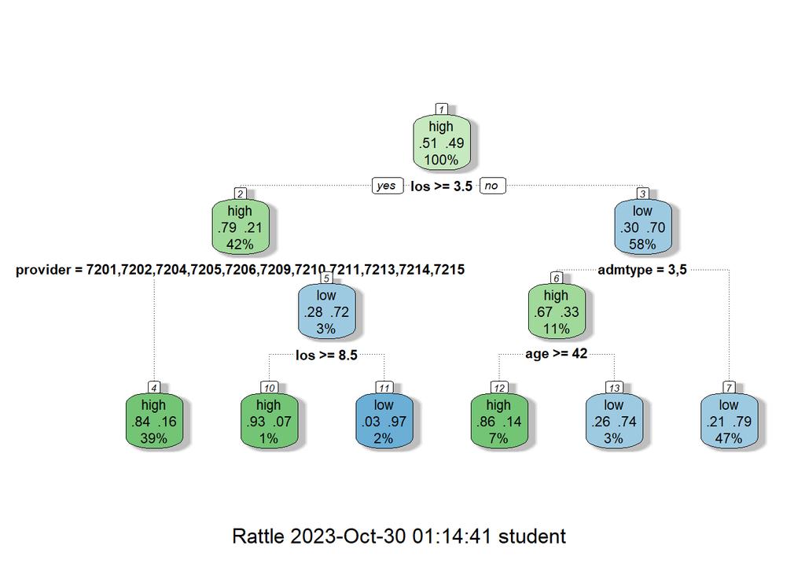

```r
library(rpart)
tree_model <- rpart(target ~ ., data = df_train,
                    control = rpart.control(maxdepth = 3))

library(rattle)
fancyRpartPlot(tree_model)
```

```r
tree_model$variable.importance
```

```
##        los    admtype   provider        age     campus   raceethn
## 1671.39077  478.46233  426.24975  229.33274   72.79847   25.20806
```

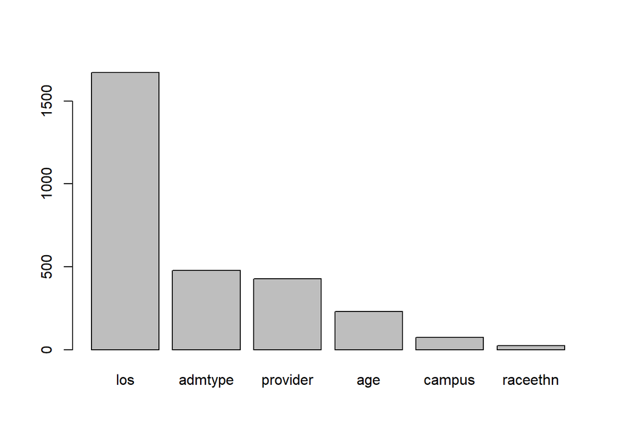

```r
barplot(tree_model$variable.importance)
```

3. Using caret for this question. Set `Training Control` to be: Use Cross-Validation of 5 folds across all models. Train & tune at least 2 different models (i.e. two different values for `method=` in the train function of caret). Plot the hyper-parameter tuning plots for each model.

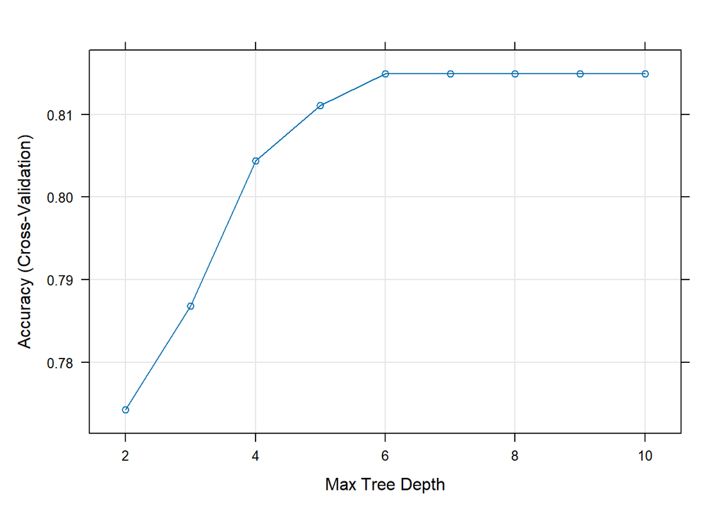

```r
tuneGrid = expand.grid(maxdepth = 2:10)
trControl = trainControl(method = "cv",
                         number = 5)
model2 <- train(target~., data=df_train,
                  method = "rpart2", trControl                        =trControl, tuneGrid = tuneGrid)
plot(model2)
```

```r
trControl1 = trainControl(method = "cv",
                         number = 5)
tuneGrid1 = expand.grid(mtry = 2:4,
          splitrule = c('gini', 'extratrees'),
           min.node.size = c(2:5))
forest_ranger <- train(target~., data=df_train,
                    method = "ranger",
                    trControl = trControl1,
                    tuneGrid = tuneGrid1)
```

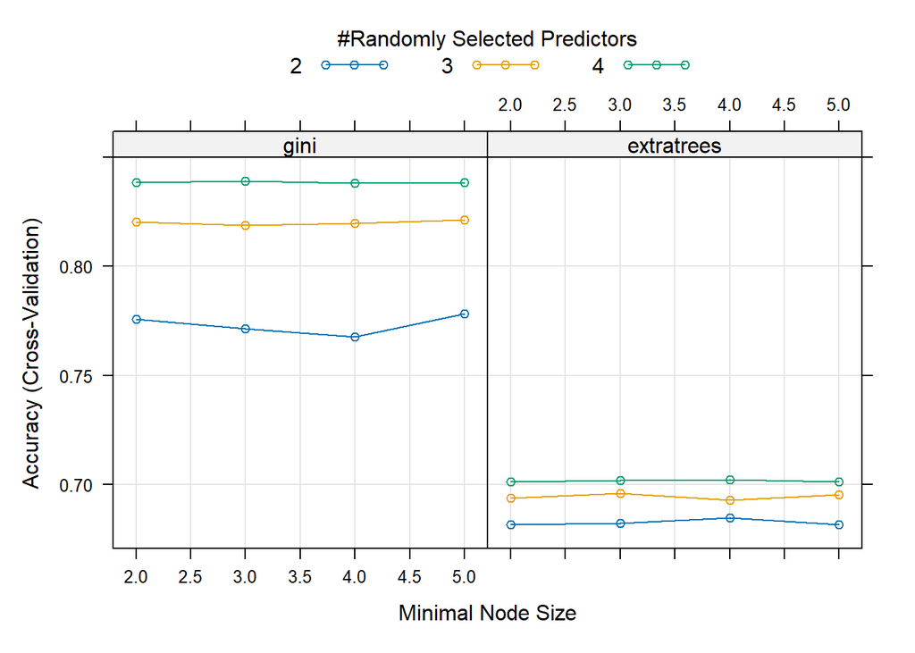

```r
plot(forest_ranger)
```

4. Plot the comparison of the models in 3.

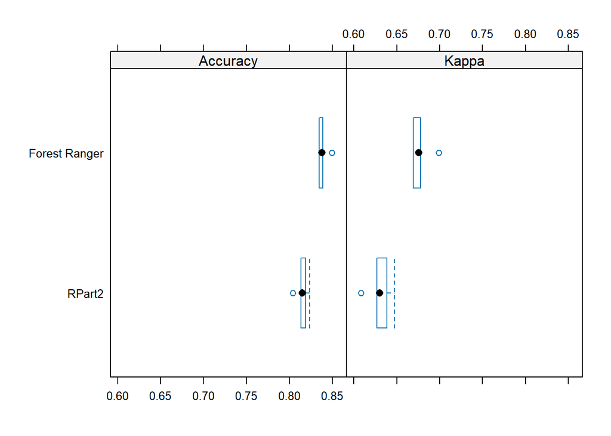

```r
results <- resamples(list('RPart2' = model2,
                          'Forest Ranger' = forest_ranger))
bwplot(results)
```

5. What is your final selection for the model? Test the accuracy of your final model on the test data.

```r
pred <- predict(model2, df_test)
cm2 <- confusionMatrix(data = pred, reference = df_test$target)
cm2$overall[1]
```

```
##  Accuracy
## 0.8127363
```

```r
pred <- predict(forest_ranger, df_test)
cm2 <- confusionMatrix(data = pred, reference = df_test$target)
cm2$overall[1]
```

```
##  Accuracy
## 0.8358688
```

```r
#The Forest Ranger Model performed slightly better
```

6. Create another `target` variable (binary), decide the input variables and redo 1 to 5.

```r
df4 <- df1

df4$target <- case_when(
    df4$sex==1 ~ 'Male',
    df4$sex==2 ~ 'Female',
    TRUE ~ 'Unknown')

df4 <- df4 %>% select(target, age, raceethn, provider, moa, mod, admtype, campus, los)

df4 <- df4 %>%
  filter(!raceethn=='',!admtype=='') %>%
  mutate(target=as.factor(target),
         age=as.numeric(age),
         raceethn=as.factor(raceethn),
         provider=as.factor(provider),
         moa=as.numeric(moa),
         mod=as.numeric(mod),
         admtype=as.factor(admtype),
         campus=as.factor(campus),
         los=as.numeric(los))


set.seed(2020)
splitIndex <- createDataPartition(df4$target, p = .1,
                                  list = FALSE)

df_train <- df4[ splitIndex,]
df_test <- df4[-splitIndex,]

model4 <- rpart(target ~ ., data = df_train,
                    control = rpart.control(maxdepth = 3))
pred <- predict(model4, df_test, type = "class")
cm <- confusionMatrix(data = pred, reference = df_test$target, positive = "Male")
cm$overall[1]
```

```
##  Accuracy
## 0.5720422
```

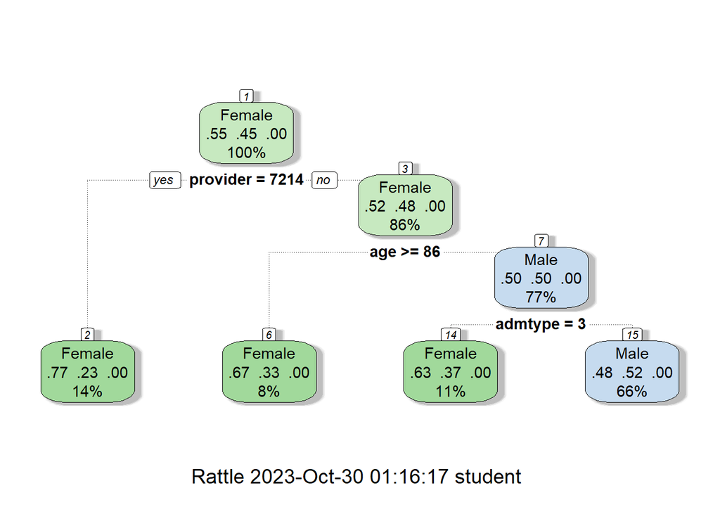

```r
fancyRpartPlot(model4)
```

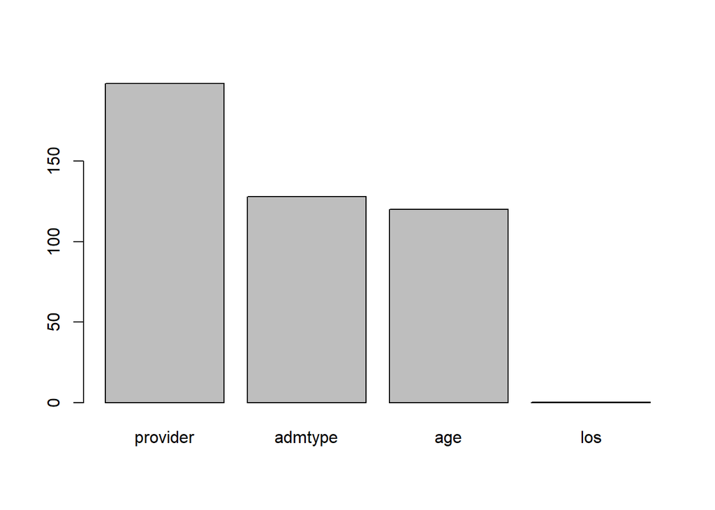

```r
barplot(model4$variable.importance)
```

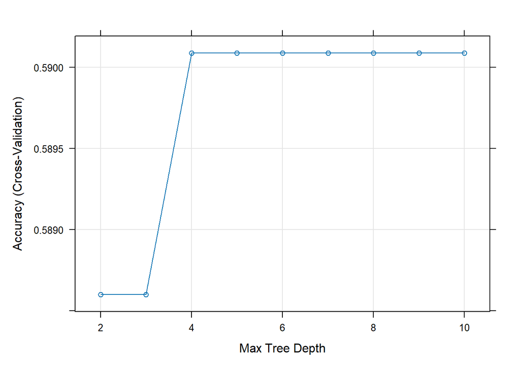

```r
tuneGrid = expand.grid(maxdepth = 2:10)
trControl = trainControl(method = "cv",
                         number = 5)
model5 <- train(target~., data=df_train,
                  method = "rpart2", trControl                        =trControl, tuneGrid = tuneGrid)
plot(model5)
```

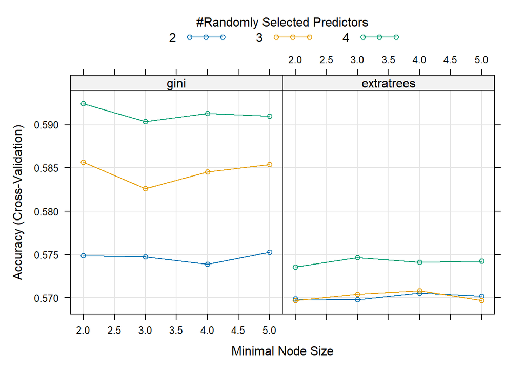

```r
trControl1 = trainControl(method = "cv",
                         number = 5)
tuneGrid1 = expand.grid(mtry = 2:4,
          splitrule = c('gini', 'extratrees'),
           min.node.size = c(2:5))
forest_ranger1 <- train(target~., data=df_train,
                    method = "ranger",
                    trControl = trControl1,
                    tuneGrid = tuneGrid1)

plot(forest_ranger1)
```

[figure not shown]

```r
results2 <- resamples(list('RPart2' = model5,
                          'Forest Ranger' = forest_ranger1))
bwplot(results)
```

```r
pred <- predict(model5, df_test)
cm2 <- confusionMatrix(data = pred, reference = df_test$target)
cm2$overall[1]
```

```
##  Accuracy
## 0.5852247
```

```r
pred <- predict(forest_ranger1, df_test)
cm3 <- confusionMatrix(data = pred, reference = df_test$target)
cm3$overall[1]
```

```
##  Accuracy
## 0.5875075
```

```r
#Ranger Forest model performed slightly better
```

7. Write a paragraph to summarize the section and give your comments on the results.

```r
#I enjoyed this section for it's practicality. With my own ideals to work as a data analyst, being able to do these kinds of processes in R would be integral for my career.
#A lot of these ideas were also fairly intuitive to me, even if I did spend a lot of time battling with my variables to make sure they functioned correctly for modeling.
```